# Describe: physical activity

This report lists the candidate variable for DataScheme variables of the construct **physact**.

# Exposition

> This report is meant to be compiled after having executed the script `./manipulation/0-ellis-island.R`, which prepares the necessary data transfer object (DTO). We begin with a brief recap of this script and the DTO it produces.

## Ellis Island

> All data land on Ellis Island.

The script `0-ellis-island.R` is the first script in the analytic workflow. It accomplished the following:

- 1. Reads in raw data files from the candidate studies
- 2. Extract, combines, and exports their metadata (specifically, variable names and labels, if provided) into `./data/shared/derived/meta-data-live.csv`, which is updated every time Ellis Island script is executed.
- 3. Augments raw metadata with instructions for renaming and classifying variables. The instructions are provided as manually entered values in `./data/shared/meta-data-map.csv`. They are used by automatic scripts in later harmonization and analysis.
- 4. Combines unit and metadata into a single DTO to serve as a starting point to all subsequent analyses.

```r
# load the product of 0-ellis-island.R,  a list object containing data and metadata
dto <- readRDS("./data/unshared/derived/dto.rds")
```

```r
# the list is composed of the following elements
names(dto)
```

```
[1] "studyName" "filePath"  "unitData"  "metaData"
```

```r
# 1st element - names of the studies as character vector
dto[["studyName"]]
```

```
[1] "alsa"  "lbsl"  "satsa" "share" "tilda"
```

```r
# 2nd element - file paths of the data files for each study as character vector
dto[["filePath"]]
```

```
[1] "./data/unshared/raw/ALSA-Wave1.Final.sav"         "./data/unshared/raw/LBSL-Panel2-Wave1.Final.sav"
[3] "./data/unshared/raw/SATSA-Q3.Final.sav"           "./data/unshared/raw/SHARE-Israel-Wave1.Final.sav"
[5] "./data/unshared/raw/TILDA-Wave1.Final.sav"
```

```r
# 3rd element - list objects with the following elements
names(dto[["unitData"]])
```

```
[1] "alsa"  "lbsl"  "satsa" "share" "tilda"
```

```r
# each of these elements is a raw data set of a corresponding study, for example
dplyr::tbl_df(dto[["unitData"]][["lbsl"]])
```

```
Source: local data frame [656 x 27]

        id AGE94 SEX94  MSTAT94 EDUC94     NOWRK94  SMK94                                         SMOKE
     (int) (int) (int)   (fctr)  (int)      (fctr) (fctr)                                        (fctr)
1  4001026    68     1 divorced     16 no, retired     no                                  never smoked
2  4012015    94     2  widowed     12 no, retired     no                                  never smoked
3  4012032    94     2  widowed     20 no, retired     no don't smoke at present but smoked in the past
4  4022004    93     2       NA     NA          NA     NA                                  never smoked
5  4022026    93     2  widowed     12 no, retired     no                                  never smoked
6  4031031    92     1  married      8 no, retired     no don't smoke at present but smoked in the past
7  4031035    92     1  widowed     13 no, retired     no don't smoke at present but smoked in the past
8  4032201    92     2       NA     NA          NA     NA don't smoke at present but smoked in the past
9  4041062    91     1  widowed      7          NA     no don't smoke at present but smoked in the past
10 4042057    91     2       NA     NA          NA     NA                                            NA
..     ...   ...   ...      ...    ...         ...    ...                                           ...
Variables not shown: ALCOHOL (fctr), WINE (int), BEER (int), HARDLIQ (int), SPORT94 (int), FIT94 (int), WALK94 (int),
  SPEC94 (int), DANCE94 (int), CHORE94 (int), EXCERTOT (int), EXCERWK (int), HEIGHT94 (int), WEIGHT94 (int), HWEIGHT
  (int), HHEIGHT (int), SRHEALTH (fctr), smoke_now (lgl), smoked_ever (lgl)
```

### Meta

```r
# 4th element - a dataset names and labels of raw variables + added metadata for all studies
dto[["metaData"]] %>% dplyr::select(study_name, name, item, construct, type, categories, label_short, label) %>%
  DT::datatable(
    class   = 'cell-border stripe',
    caption = "This is the primary metadata file. Edit at `./data/shared/meta-data-map.csv",
    filter  = "top",
    options = list(pageLength = 6, autoWidth = TRUE)
  )
```

|  | study_name | name | item | construct | type | categories | label_short | label |
| --- | --- | --- | --- | --- | --- | --- | --- | --- |
| 1 | alsa | SEQNUM | id | id | demo | 2087 | Sequence Number | Sequence Number |
| 2 | alsa | EXRTHOUS |  | physact | activity |  | Exertion around house | Exertion around house |
| 3 | alsa | HWMNWK2W |  | physact | activity |  | Times walked in past two weeks | Times walked in past two weeks |
| 4 | alsa | LSVEXC2W |  | physact | activity |  | Less vigor sessions last 2 weeks | Less vigor sessions last 2 weeks |
| 5 | alsa | LSVIGEXC |  | physact | activity |  | Less vigor past 2 weeks | Less vigor past 2 weeks |
| 6 | alsa | TMHVYEXR |  | physact | activity |  | Time heavy physical exertion | Time heavy physical exertion |
| 7 | alsa | TMVEXC2W |  | physact | activity |  | Vigor Time past 2 weeks | Vigor Time past 2 weeks |
| 8 | alsa | VIGEXC2W |  | physact | activity |  | Vigor Sessions in past 2 weeks | Vigor Sessions in past 2 weeks |
| 9 | alsa | VIGEXCS |  | physact | activity |  | Vigorous exercise | Vigorous exercise |
| 10 | alsa | WALK2WKS |  | physact | activity |  | Walking past 2 weeks | Walking past 2 weeks |

[output cut: 140 more lines]

# ALSA

## EXRTHOUS

```r
dto[["metaData"]]%>%dplyr::filter(study_name=="alsa", name=="EXRTHOUS")%>%dplyr::select(name,label)
```

```
      name                 label
1 EXRTHOUS Exertion around house
```

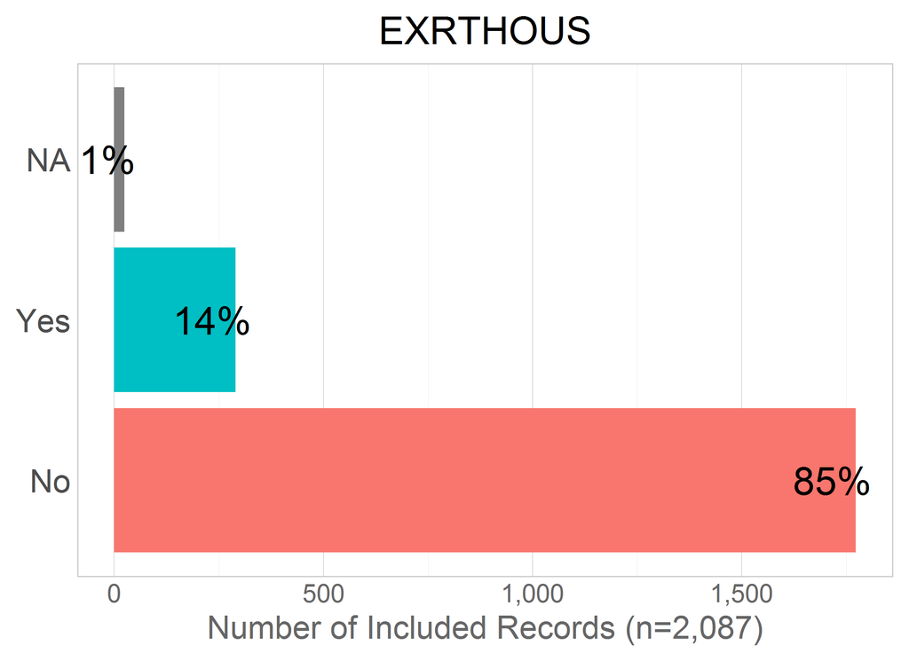

```r
dto[["unitData"]][["alsa"]]%>%histogram_discrete("EXRTHOUS")
```

```r
dto[["unitData"]][["alsa"]]%>%dplyr::group_by_("EXRTHOUS")%>%dplyr::summarize(n=n())
```

```
Source: local data frame [3 x 2]

  EXRTHOUS     n
    (fctr) (int)
1      Yes   290
2       No  1773
3       NA    24
```

## HWMNWK2W

```r
dto[["metaData"]] %>% dplyr::filter(study_name=="alsa", name=="HWMNWK2W") %>% dplyr::select(name,label)
```

```
      name                          label
1 HWMNWK2W Times walked in past two weeks
```

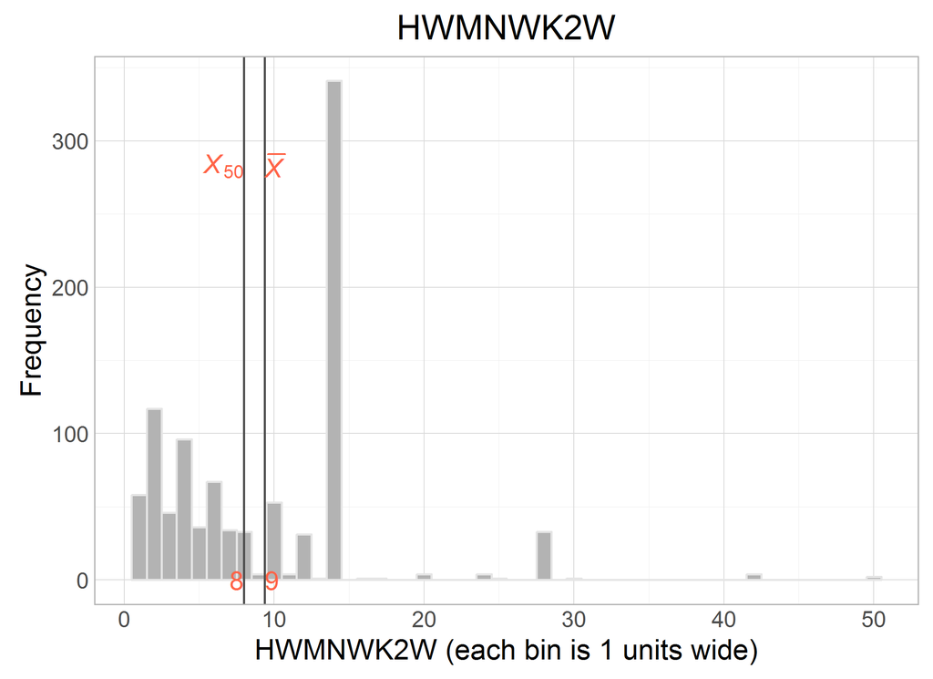

```r
dto[["unitData"]][["alsa"]]%>% histogram_continuous("HWMNWK2W", bin_width=1)
```

```r
dto[["unitData"]][["alsa"]]%>% dplyr::group_by_("HWMNWK2W") %>% dplyr::summarize(n=n())
```

```
Source: local data frame [24 x 2]

   HWMNWK2W     n
      (int) (int)
1         1    58
2         2   117
3         3    46
4         4    96
5         5    36
6         6    67
7         7    34
8         8    33
9         9     4
10       10    53
..      ...   ...
```

## LSVEXC2W

```r
dto[["metaData"]] %>% dplyr::filter(study_name=="alsa", name=="LSVEXC2W") %>% dplyr::select(name,label)
```

```
      name                            label
1 LSVEXC2W Less vigor sessions last 2 weeks
```

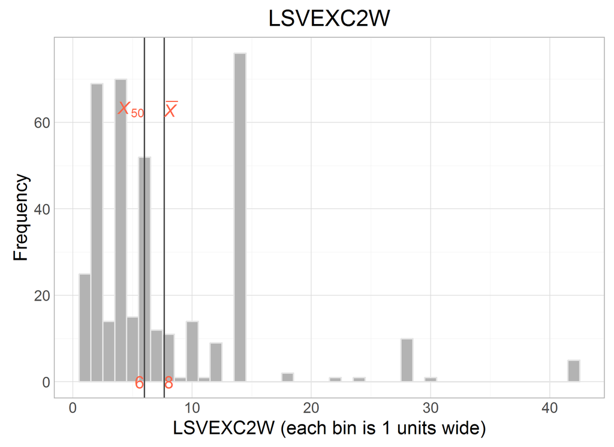

```r
dto[["unitData"]][["alsa"]]%>% histogram_continuous("LSVEXC2W", bin_width=1)
```

```r
dto[["unitData"]][["alsa"]]%>% dplyr::group_by_("LSVEXC2W") %>% dplyr::summarize(n=n())
```

```
Source: local data frame [20 x 2]

   LSVEXC2W     n
      (int) (int)
1         1    25
2         2    69
3         3    14
4         4    70
5         5    15
6         6    52
7         7    12
8         8    11
9         9     1
10       10    14
11       11     1
12       12     9
13       14    76
14       18     2
15       22     1
16       24     1
17       28    10
18       30     1
19       42     5
20       NA  1698
```

## LSVIGEXC

```r
dto[["metaData"]]%>%dplyr::filter(study_name=="alsa", name=="LSVIGEXC")%>%dplyr::select(name,label)
```

```
      name                   label
1 LSVIGEXC Less vigor past 2 weeks
```

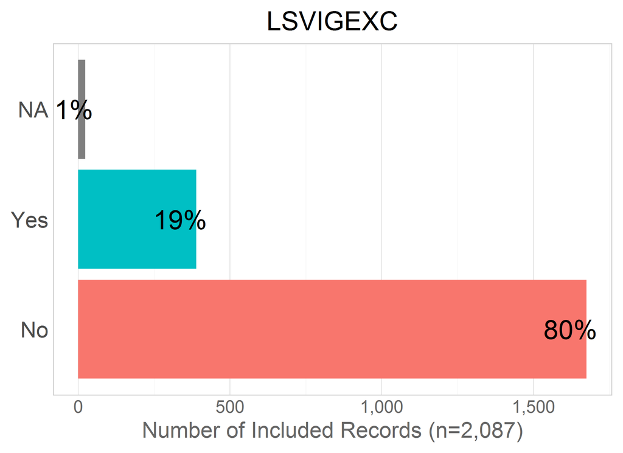

```r
dto[["unitData"]][["alsa"]]%>%histogram_discrete("LSVIGEXC")
```

```r
dto[["unitData"]][["alsa"]]%>%dplyr::group_by_("LSVIGEXC")%>%dplyr::summarize(n=n())
```

```
Source: local data frame [3 x 2]

  LSVIGEXC     n
    (fctr) (int)
1      Yes   389
2       No  1675
3       NA    23
```

## TMHVYEXR

```r
dto[["metaData"]]%>%dplyr::filter(study_name=="alsa", name=="TMHVYEXR")%>%dplyr::select(name,label)
```

```
      name                        label
1 TMHVYEXR Time heavy physical exertion
```

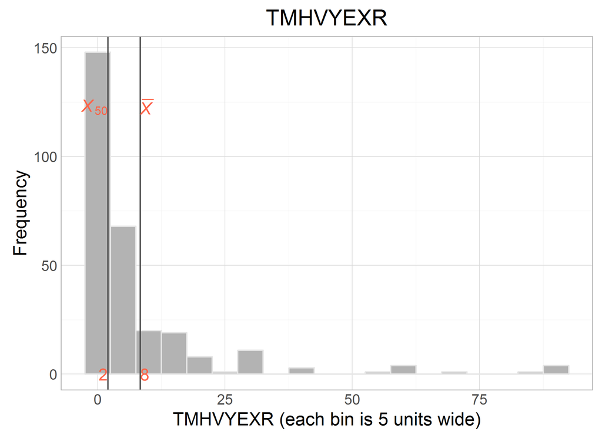

```r
dto[["unitData"]][["alsa"]]%>%histogram_continuous("TMHVYEXR", bin_width=5)
```

```r
dto[["unitData"]][["alsa"]]%>%dplyr::group_by_("TMHVYEXR")%>%dplyr::summarize(n=n())
```

```
Source: local data frame [27 x 2]

   TMHVYEXR     n
      (int) (int)
1         1    77
2         2    71
3         3    15
4         4    30
5         5    11
6         6     8
7         7     4
8         8     7
9        10    11
10       11     1
..      ...   ...
```

## TMVEXC2W

```r
dto[["metaData"]]%>%dplyr::filter(study_name=="alsa", name=="TMVEXC2W")%>%dplyr::select(name,label)
```

```
      name                   label
1 TMVEXC2W Vigor Time past 2 weeks
```

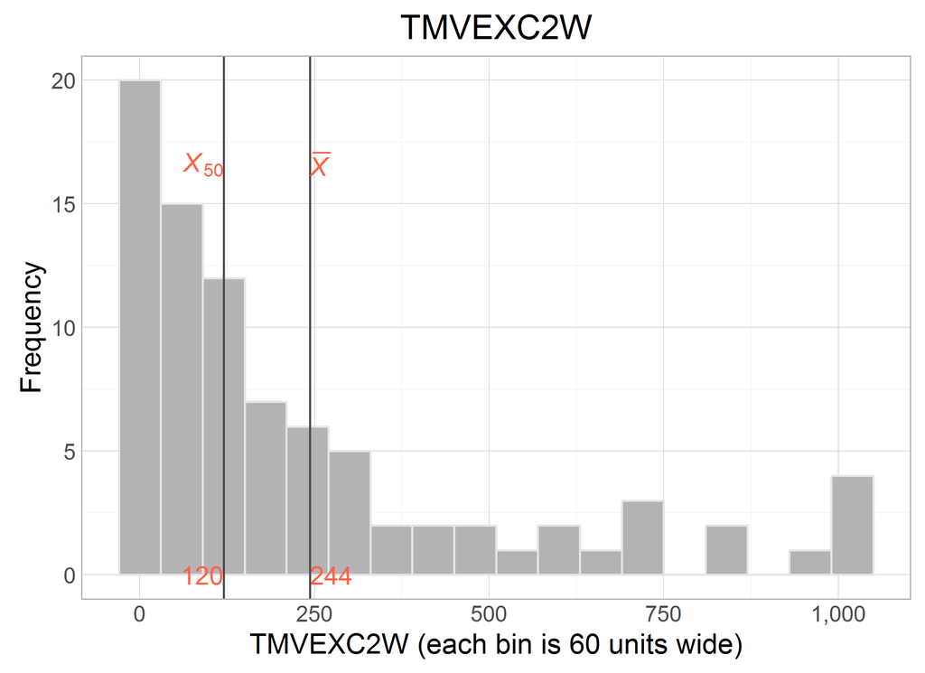

```r
dto[["unitData"]][["alsa"]]%>%histogram_continuous("TMVEXC2W", bin_width=60)
```

```r
dto[["unitData"]][["alsa"]]%>%dplyr::group_by_("TMVEXC2W")%>%dplyr::summarize(n=n())
```

```
Source: local data frame [37 x 2]

   TMVEXC2W     n
      (int) (int)
1         1     1
2         2     1
3         4     3
4         5     2
5         8     4
6        10     1
7        11     1
8        14     1
9        18     1
10       21     1
..      ...   ...
```

## VIGEXC2W

```r
dto[["metaData"]]%>%dplyr::filter(study_name=="alsa", name=="VIGEXC2W")%>%dplyr::select(name,label)
```

```
      name                          label
1 VIGEXC2W Vigor Sessions in past 2 weeks
```

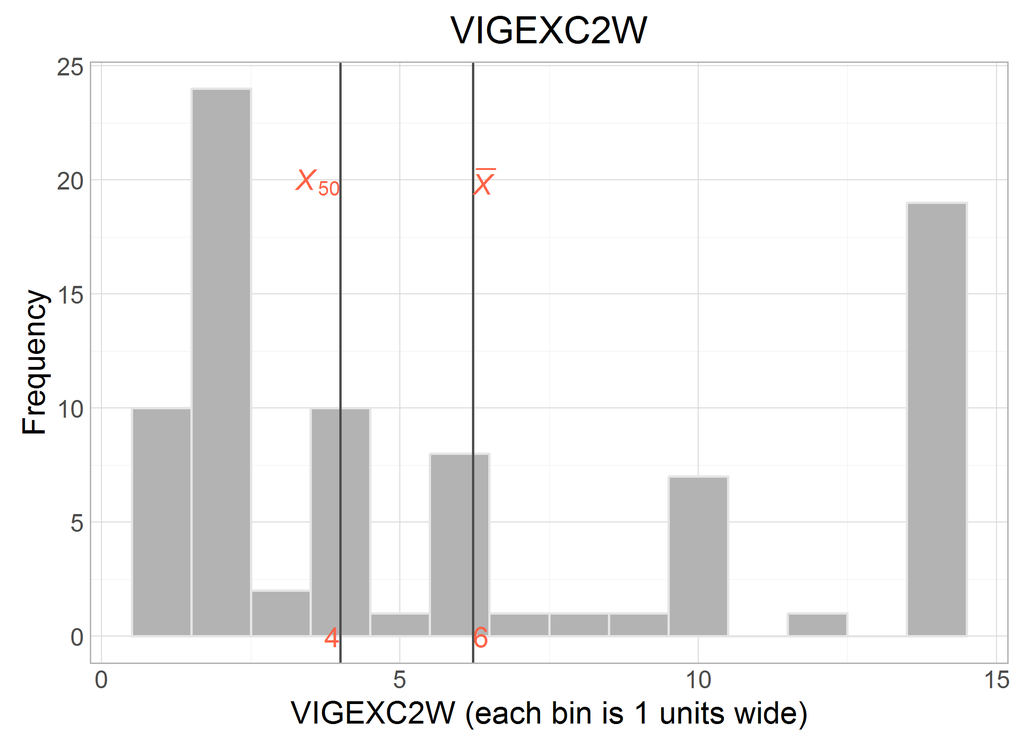

```r
dto[["unitData"]][["alsa"]]%>%histogram_continuous("VIGEXC2W", bin_width=1)
```

```r
dto[["unitData"]][["alsa"]]%>%dplyr::group_by_("VIGEXC2W")%>%dplyr::summarize(n=n())
```

```
Source: local data frame [13 x 2]

   VIGEXC2W     n
      (int) (int)
1         1    10
2         2    24
3         3     2
4         4    10
5         5     1
6         6     8
7         7     1
8         8     1
9         9     1
10       10     7
11       12     1
12       14    19
13       NA  2002
```

## VIGEXCS

```r
dto[["metaData"]]%>%dplyr::filter(study_name=="alsa", name=="VIGEXCS")%>%dplyr::select(name,label)
```

```
     name             label
1 VIGEXCS Vigorous exercise
```

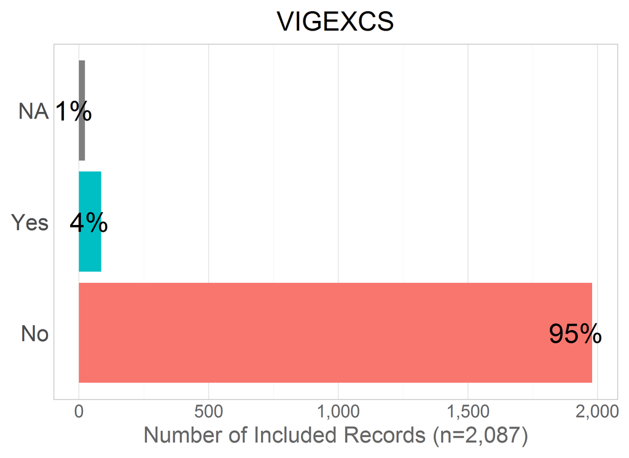

```r
dto[["unitData"]][["alsa"]]%>%histogram_discrete("VIGEXCS")
```

```r
dto[["unitData"]][["alsa"]]%>%dplyr::group_by_("VIGEXCS")%>%dplyr::summarize(n=n())
```

```
Source: local data frame [3 x 2]

  VIGEXCS     n
   (fctr) (int)
1     Yes    85
2      No  1979
3      NA    23
```

## WALK2WKS

```r
dto[["metaData"]]%>%dplyr::filter(study_name=="alsa", name=="WALK2WKS")%>%dplyr::select(name,label)
```

```
      name                label
1 WALK2WKS Walking past 2 weeks
```

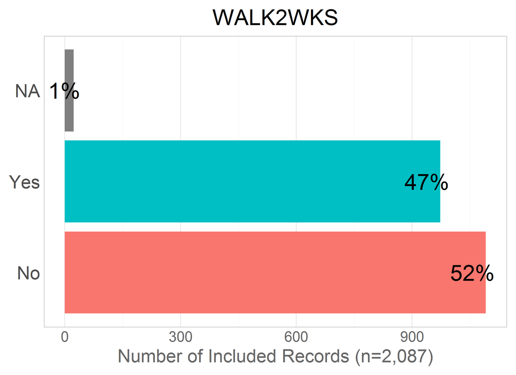

```r
dto[["unitData"]][["alsa"]]%>%histogram_discrete("WALK2WKS")
```

```r
dto[["unitData"]][["alsa"]]%>%dplyr::group_by_("WALK2WKS")%>%dplyr::summarize(n=n())
```

```
Source: local data frame [3 x 2]

  WALK2WKS     n
    (fctr) (int)
1      Yes   973
2       No  1091
3       NA    23
```

# LBSL

## CHORE94

```r
dto[["metaData"]]%>%dplyr::filter(study_name=="lbsl", name=="CHORE94")%>%dplyr::select(name,label)
```

```
     name                                                  label
1 CHORE94 Doing household chores, number of hours spent per week
```

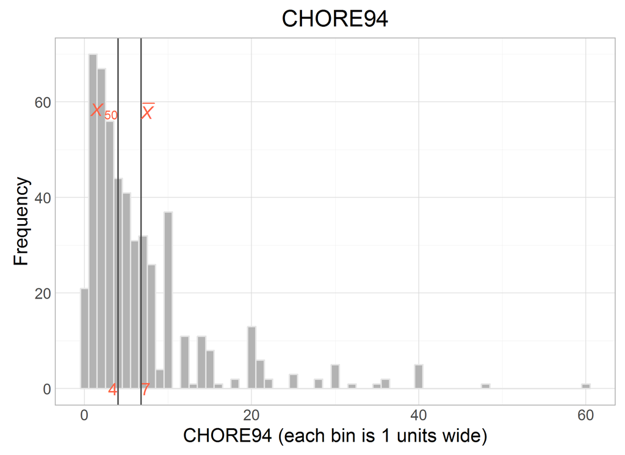

```r
dto[["unitData"]][["lbsl"]]%>%histogram_continuous("CHORE94", bin_width=1)
```

```r
dto[["unitData"]][["lbsl"]]%>%dplyr::group_by_("CHORE94")%>%dplyr::summarize(n=n())
```

```
Source: local data frame [30 x 2]

   CHORE94     n
     (int) (int)
1        0    21
2        1    70
3        2    67
4        3    56
5        4    44
6        5    41
7        6    31
8        7    32
9        8    26
10       9     4
..     ...   ...
```

## DANCE94

```r
dto[["metaData"]]%>%dplyr::filter(study_name=="lbsl", name=="DANCE94")%>%dplyr::select(name,label)
```

```
     name   label
1 DANCE94 Dancing
```

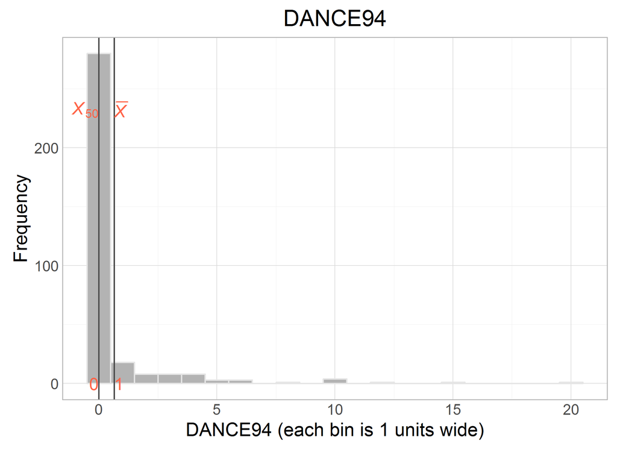

```r
dto[["unitData"]][["lbsl"]]%>%histogram_continuous("DANCE94", bin_width=1)
```

```r
dto[["unitData"]][["lbsl"]]%>%dplyr::group_by_("DANCE94")%>%dplyr::summarize(n=n())
```

```
Source: local data frame [13 x 2]

   DANCE94     n
     (int) (int)
1        0   280
2        1    18
3        2     8
4        3     8
5        4     8
6        5     3
7        6     3
8        8     1
9       10     4
10      12     1
11      15     1
12      20     1
13      NA   320
```

## EXCERTOT

```r
dto[["metaData"]]%>%dplyr::filter(study_name=="lbsl", name=="EXCERTOT")%>%dplyr::select(name,label)
```

```
      name                                                                             label
1 EXCERTOT Number of total hours in an average week exercising for shape/fun (not housework)
```

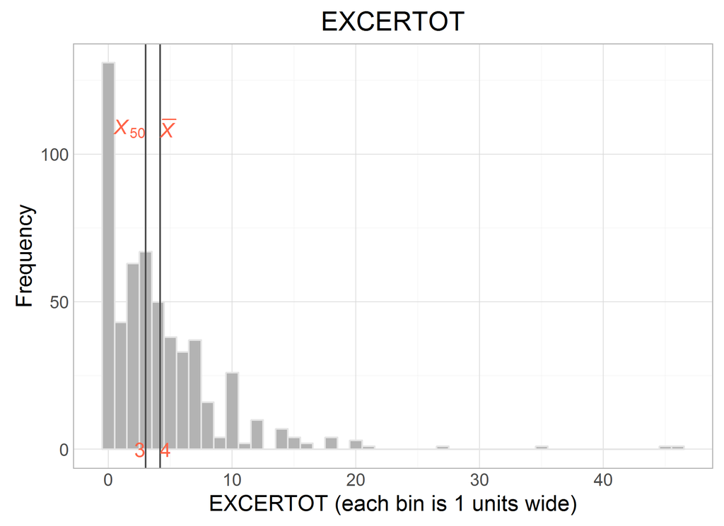

```r
dto[["unitData"]][["lbsl"]]%>%histogram_continuous("EXCERTOT", bin_width=1)
```

```r
dto[["unitData"]][["lbsl"]]%>%dplyr::group_by_("EXCERTOT")%>%dplyr::summarize(n=n())
```

```
Source: local data frame [24 x 2]

   EXCERTOT     n
      (int) (int)
1         0   131
2         1    43
3         2    63
4         3    67
5         4    50
6         5    38
7         6    33
8         7    37
9         8    16
10        9     4
..      ...   ...
```

## EXCERWK

```r
dto[["metaData"]]%>%dplyr::filter(study_name=="lbsl", name=="EXCERWK")%>%dplyr::select(name,label)
```

```
     name                                                   label
1 EXCERWK Number of times in past week exercised or played sports
```

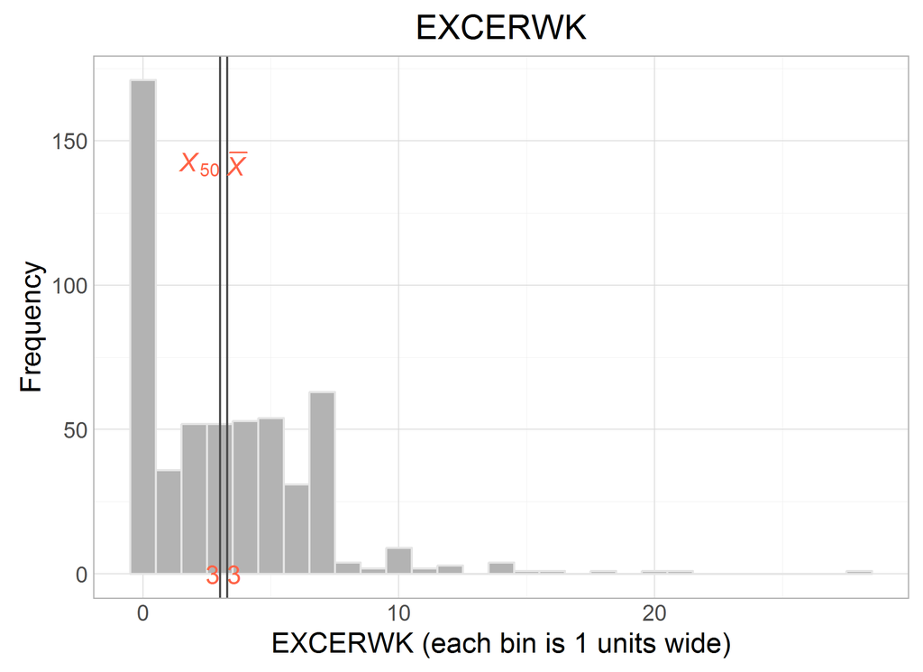

```r
dto[["unitData"]][["lbsl"]]%>%histogram_continuous("EXCERWK", bin_width=1)
```

```r
dto[["unitData"]][["lbsl"]]%>%dplyr::group_by_("EXCERWK")%>%dplyr::summarize(n=n())
```

```
Source: local data frame [21 x 2]

   EXCERWK     n
     (int) (int)
1        0   171
2        1    36
3        2    52
4        3    52
5        4    53
6        5    54
7        6    31
8        7    63
9        8     4
10       9     2
..     ...   ...
```

## FIT94

```r
dto[["metaData"]]%>%dplyr::filter(study_name=="lbsl", name=="FIT94")%>%dplyr::select(name,label)
```

```
   name                                       label
1 FIT94 Physical fitness, number of hours each week
```

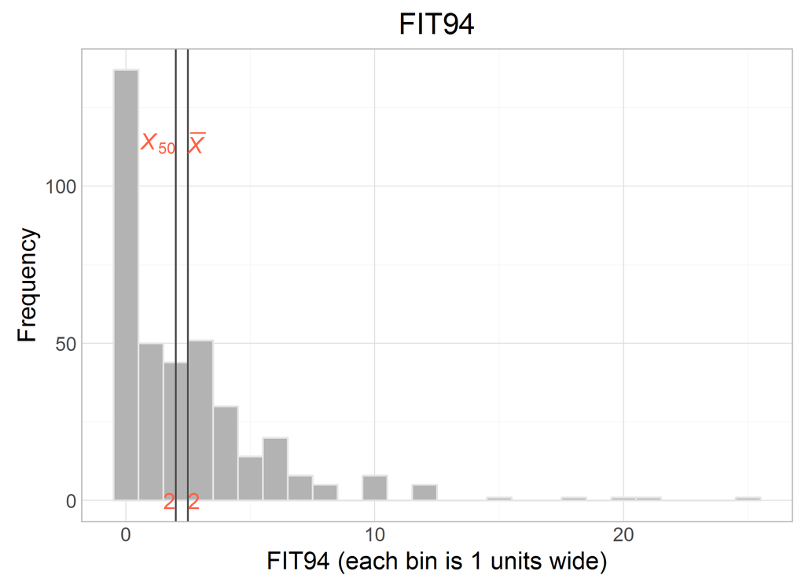

```r
dto[["unitData"]][["lbsl"]]%>%histogram_continuous("FIT94", bin_width=1)
```

```r
dto[["unitData"]][["lbsl"]]%>%dplyr::group_by_("FIT94")%>%dplyr::summarize(n=n())
```

```
Source: local data frame [17 x 2]

   FIT94     n
   (int) (int)
1      0   137
2      1    50
3      2    44
4      3    51
5      4    30
6      5    14
7      6    20
8      7     8
9      8     5
10    10     8
11    12     5
12    15     1
13    18     1
14    20     1
15    21     1
16    25     1
17    NA   279
```

## SPEC94

```r
dto[["metaData"]]%>%dplyr::filter(study_name=="lbsl", name=="SPEC94")%>%dplyr::select(name,label)
```

```
    name                                            label
1 SPEC94 Spectator sports, number of hours spent per week
```

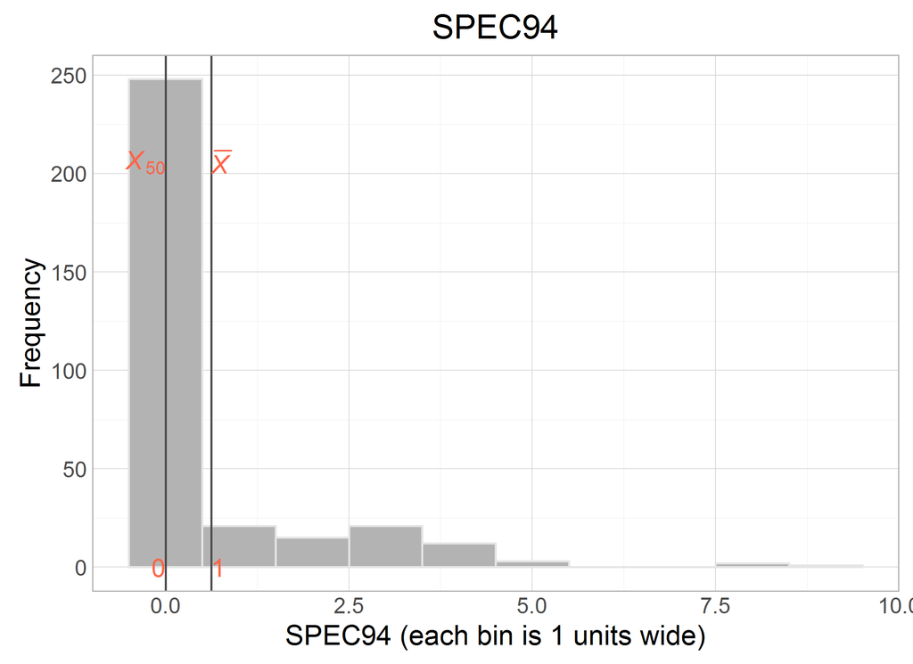

```r
dto[["unitData"]][["lbsl"]]%>%histogram_continuous("SPEC94", bin_width=1)
```

```r
dto[["unitData"]][["lbsl"]]%>%dplyr::group_by_("SPEC94")%>%dplyr::summarize(n=n())
```

```
Source: local data frame [9 x 2]

  SPEC94     n
   (int) (int)
1      0   248
2      1    21
3      2    15
4      3    21
5      4    12
6      5     3
7      8     2
8      9     1
9     NA   333
```

## SPORT94

```r
dto[["metaData"]]%>%dplyr::filter(study_name=="lbsl", name=="SPORT94")%>%dplyr::select(name,label)
```

```
     name                               label
1 SPORT94 Participant sports, number of hours
```

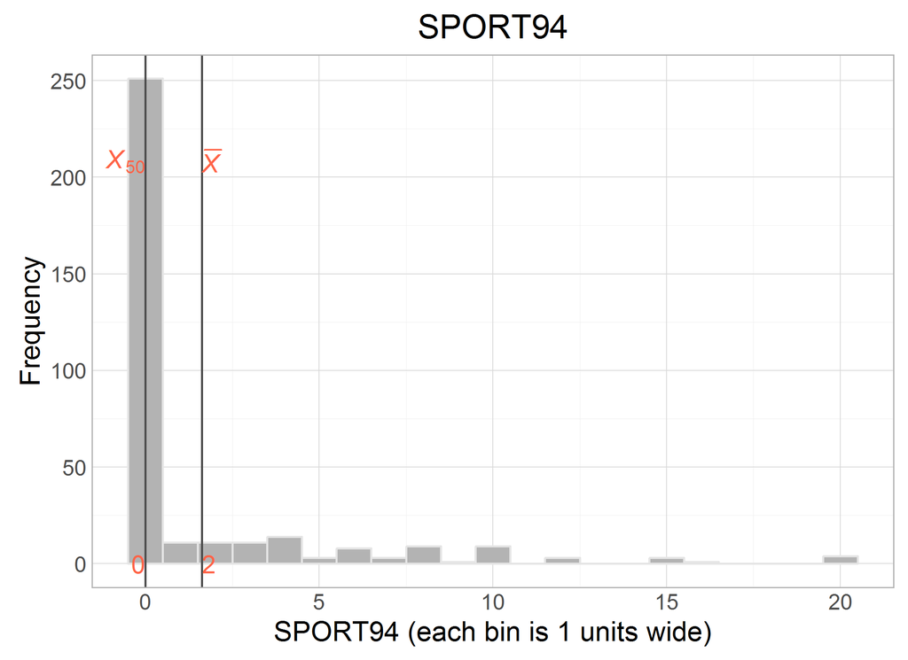

```r
dto[["unitData"]][["lbsl"]]%>%histogram_continuous("SPORT94", bin_width=1)
```

```r
dto[["unitData"]][["lbsl"]]%>%dplyr::group_by_("SPORT94")%>%dplyr::summarize(n=n())
```

```
Source: local data frame [16 x 2]

   SPORT94     n
     (int) (int)
1        0   251
2        1    11
3        2    11
4        3    11
5        4    14
6        5     3
7        6     8
8        7     3
9        8     9
10       9     1
11      10     9
12      12     3
13      15     3
14      16     1
15      20     4
16      NA   314
```

## WALK94

```r
dto[["metaData"]]%>%dplyr::filter(study_name=="lbsl", name=="WALK94")%>%dplyr::select(name,label)
```

```
    name                             label
1 WALK94 Walking, number of hours per week
```

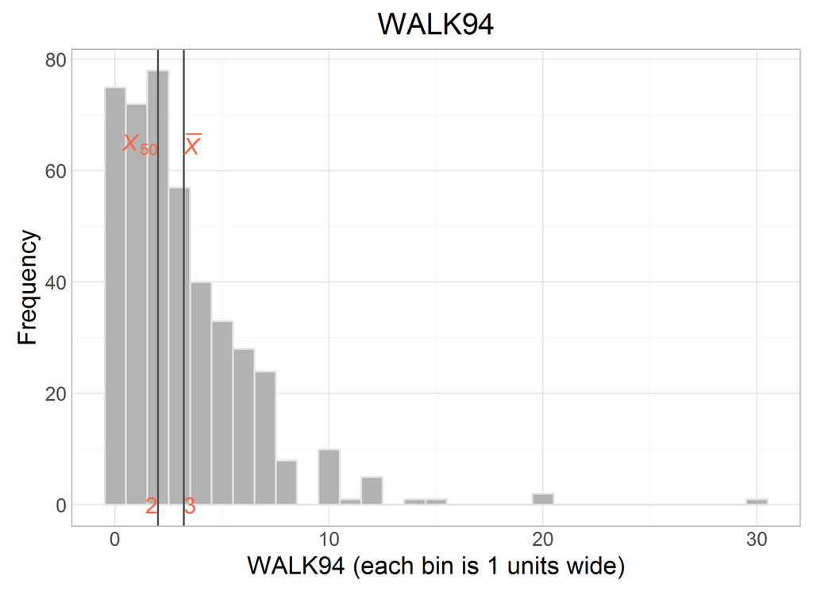

```r
dto[["unitData"]][["lbsl"]]%>%histogram_continuous("WALK94", bin_width=1)
```

```r
dto[["unitData"]][["lbsl"]]%>%dplyr::group_by_("WALK94")%>%dplyr::summarize(n=n())
```

```
Source: local data frame [17 x 2]

   WALK94     n
    (int) (int)
1       0    75
2       1    72
3       2    78
4       3    57
5       4    40
6       5    33
7       6    28
8       7    24
9       8     8
10     10    10
11     11     1
12     12     5
13     14     1
14     15     1
15     20     2
16     30     1
17     NA   220
```

# SATSA

## GEXERCIS

```r
dto[["metaData"]]%>%dplyr::filter(study_name=="satsa", name=="GEXERCIS")%>%dplyr::select(name,label)
```

```
      name
1 GEXERCIS
                                                                                                                                                             label
1 Here are seven different options concerning exercise during your leisure time. Which one of these options best fits how you yourself exercise on a yearly basis?
```

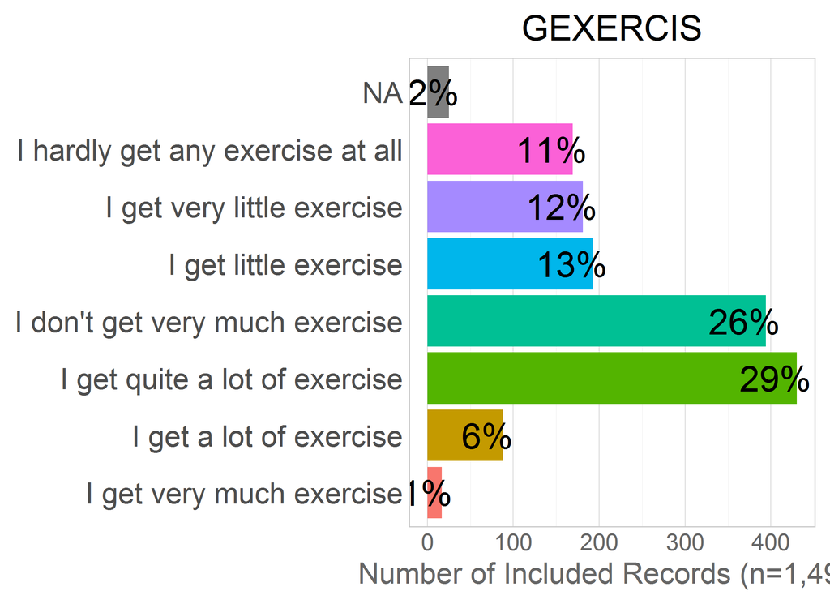

```r
dto[["unitData"]][["satsa"]]%>%histogram_discrete("GEXERCIS")
```

```r
dto[["unitData"]][["satsa"]]%>%dplyr::group_by_("GEXERCIS")%>%dplyr::summarize(n=n())
```

```
Source: local data frame [8 x 2]

                          GEXERCIS     n
                            (fctr) (int)
1 I hardly get any exercise at all   169
2       I get very little exercise   181
3            I get little exercise   193
4   I don't get very much exercise   394
5    I get quite a lot of exercise   430
6          I get a lot of exercise    88
7         I get very much exercise    17
8                               NA    25
```

# SHARE

## BR0150

```r
dto[["metaData"]]%>%dplyr::filter(study_name=="share", name=="BR0150")%>%dplyr::select(name,label)
```

```
    name                                  label
1 BR0150 sports or activities that are vigorous
```

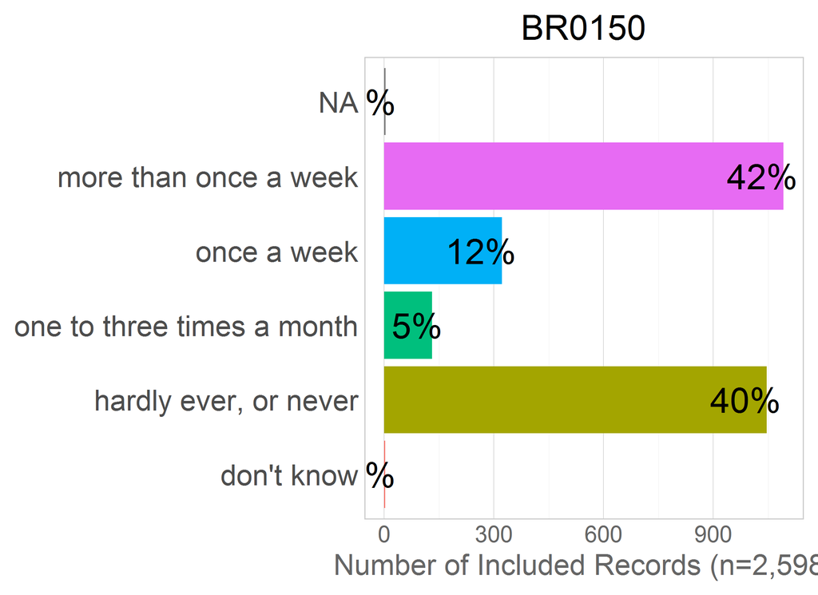

```r
dto[["unitData"]][["share"]]%>%histogram_discrete("BR0150")
```

```r
dto[["unitData"]][["share"]]%>%dplyr::group_by_("BR0150")%>%dplyr::summarize(n=n())
```

```
Source: local data frame [6 x 2]

                      BR0150     n
                      (fctr) (int)
1      more than once a week  1092
2                once a week   322
3 one to three times a month   131
4      hardly ever, or never  1046
5                 don't know     3
6                         NA     4
```

## BR0160

```r
dto[["metaData"]]%>%dplyr::filter(study_name=="share", name=="BR0160")%>%dplyr::select(name,label)
```

```
    name                                           label
1 BR0160 activities requiring a moderate level of energy
```

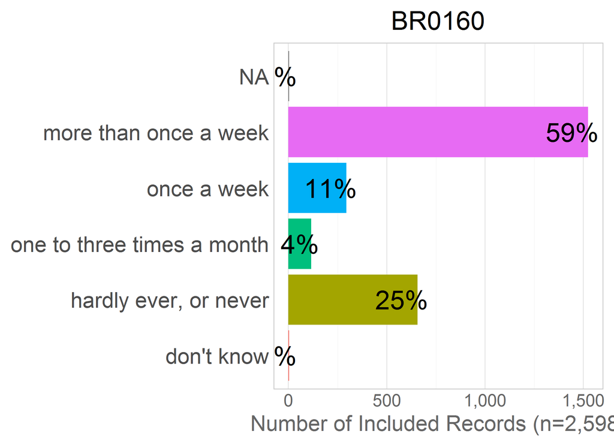

```r
dto[["unitData"]][["share"]]%>%histogram_discrete("BR0160")
```

```r
dto[["unitData"]][["share"]]%>%dplyr::group_by_("BR0160")%>%dplyr::summarize(n=n())
```

```
Source: local data frame [6 x 2]

                      BR0160     n
                      (fctr) (int)
1      more than once a week  1524
2                once a week   294
3 one to three times a month   116
4      hardly ever, or never   657
5                 don't know     3
6                         NA     4
```

# TILDA

## BH101

```r
dto[["metaData"]]%>%dplyr::filter(study_name=="tilda", name=="BH101")%>%dplyr::select(name,label)
```

```
   name                                                                                 label
1 BH101 bh101  During the last 7 days, on how many days did you do vigorous physical activit?
```

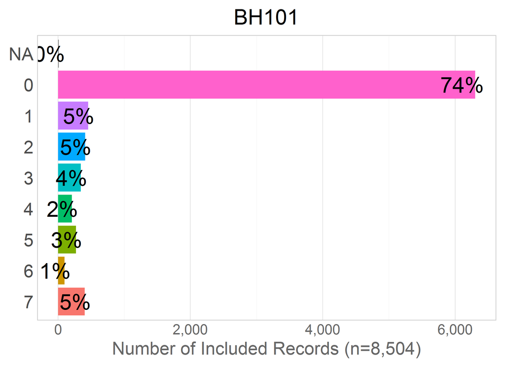

```r
dto[["unitData"]][["tilda"]]%>%histogram_discrete("BH101")
```

```r
dto[["unitData"]][["tilda"]]%>%dplyr::group_by_("BH101")%>%dplyr::summarize(n=n())
```

```
Source: local data frame [9 x 2]

  BH101     n
  (int) (int)
1     0  6303
2     1   454
3     2   409
4     3   346
5     4   208
6     5   272
7     6    97
8     7   403
9    NA    12
```

## BH102

```r
dto[["metaData"]]%>%dplyr::filter(study_name=="tilda", name=="BH102")%>%dplyr::select(name,label)
```

```
   name                                                                                 label
1 BH102 bh102  How much time did you usually spend doing vigorous physical activities on one?
```

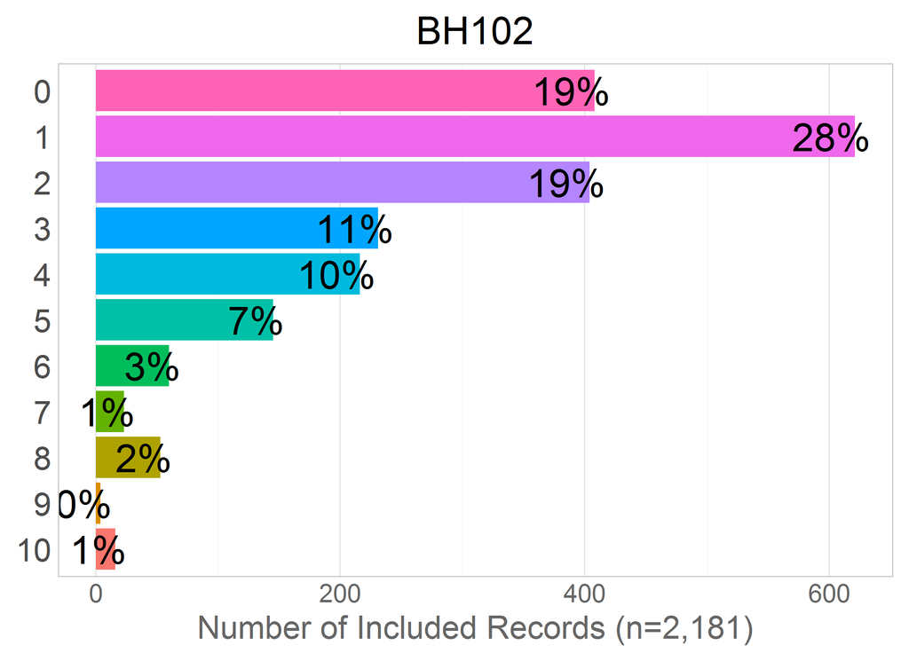

```r
dto[["unitData"]][["tilda"]] %>% dplyr::filter(!BH102==-1)%>%histogram_discrete("BH102")
```

```r
dto[["unitData"]][["tilda"]]%>%dplyr::group_by_("BH102")%>%dplyr::summarize(n=n())
```

```
Source: local data frame [13 x 2]

   BH102     n
   (int) (int)
1     -1  6314
2      0   408
3      1   621
4      2   404
5      3   231
6      4   216
7      5   145
8      6    60
9      7    23
10     8    53
11     9     4
12    10    16
13    NA     9
```

## BH102A

```r
dto[["metaData"]]%>%dplyr::filter(study_name=="tilda", name=="BH102A")%>%dplyr::select(name,label)
```

```
    name                                                                                  label
1 BH102A bh102a  How much time did you usually spend doing vigorous physical activities on one?
```

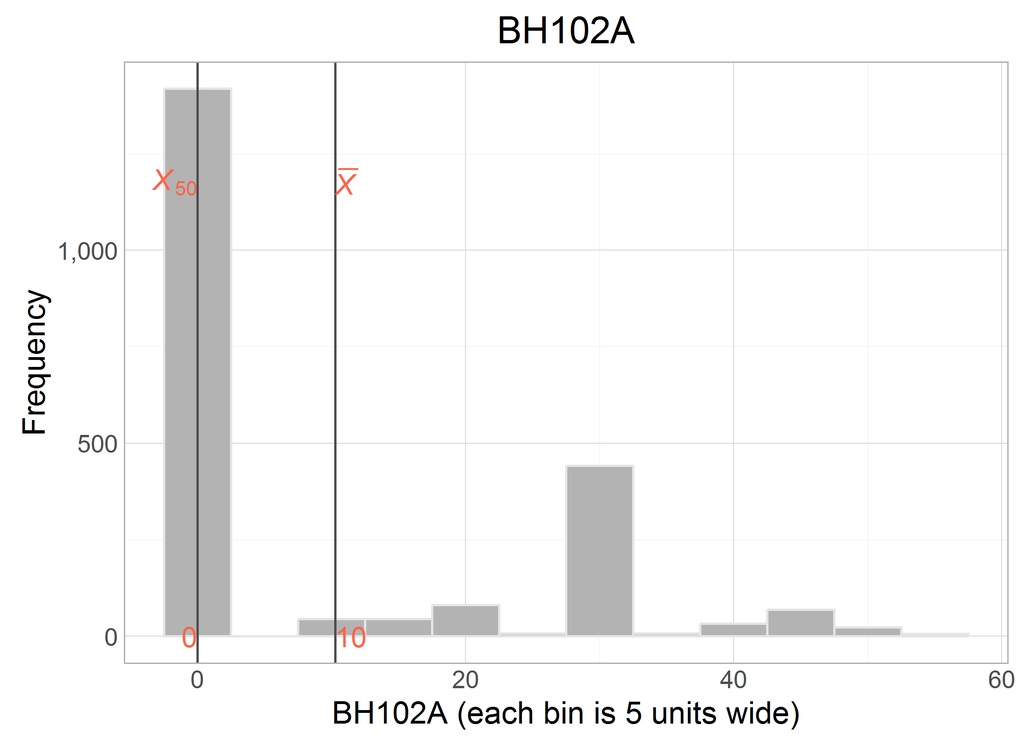

```r
dto[["unitData"]][["tilda"]]%>% dplyr::filter(!BH102A==-1)%>%histogram_continuous("BH102A", bin_width=5)
```

```r
dto[["unitData"]][["tilda"]]%>%dplyr::group_by_("BH102A")%>%dplyr::summarize(n=n())
```

```
Source: local data frame [16 x 2]

   BH102A     n
    (int) (int)
1      -1  6314
2       0  1418
3      10    45
4      14     1
5      15    44
6      20    81
7      24     1
8      25     7
9      28     1
10     30   441
11     35     8
12     40    33
13     45    69
14     50    23
15     55     6
16     NA    12
```

## BH103

```r
dto[["metaData"]]%>%dplyr::filter(study_name=="tilda", name=="BH103")%>%dplyr::select(name,label)
```

```
   name                                                                                 label
1 BH103 bh103  During the last 7 days, on how many days did you do moderate physical activit?
```

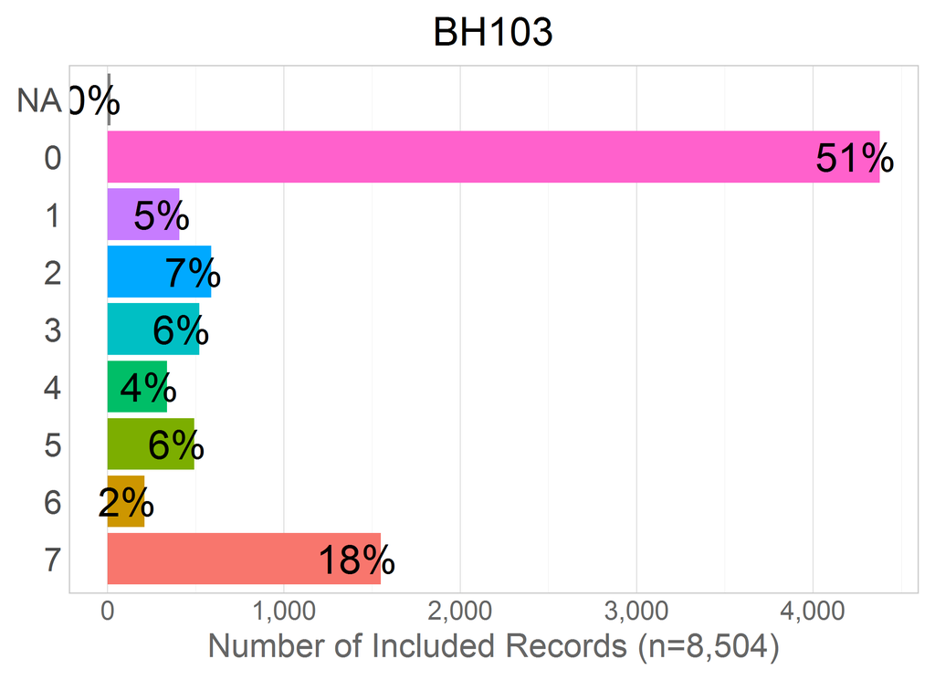

```r
dto[["unitData"]][["tilda"]]%>%histogram_discrete("BH103")
```

```r
dto[["unitData"]][["tilda"]]%>%dplyr::group_by_("BH103")%>%dplyr::summarize(n=n())
```

```
Source: local data frame [9 x 2]

  BH103     n
  (int) (int)
1     0  4378
2     1   409
3     2   589
4     3   521
5     4   338
6     5   493
7     6   210
8     7  1549
9    NA    17
```

## BH104

```r
dto[["metaData"]]%>%dplyr::filter(study_name=="tilda", name=="BH104")%>%dplyr::select(name,label)
```

```
   name                                                                                 label
1 BH104 bh104  How much time did you usually spend doing moderate physical activities on one?
```

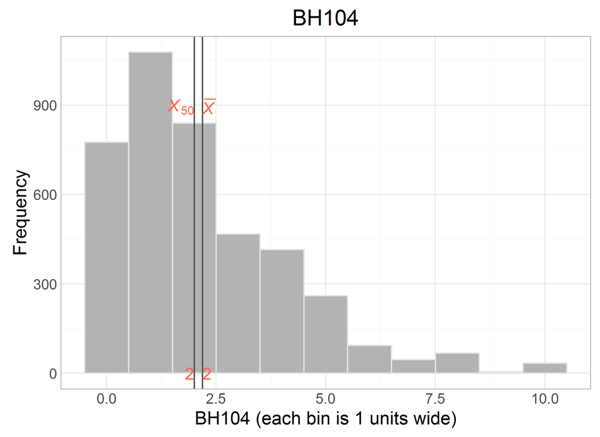

```r
dto[["unitData"]][["tilda"]]%>% dplyr::filter(!BH104==-1)%>%histogram_continuous("BH104", bin_width=1)
```

```r
dto[["unitData"]][["tilda"]]%>%dplyr::group_by_("BH104")%>%dplyr::summarize(n=n())
```

```
Source: local data frame [13 x 2]

   BH104     n
   (int) (int)
1     -1  4395
2      0   776
3      1  1078
4      2   840
5      3   468
6      4   416
7      5   261
8      6    94
9      7    46
10     8    68
11     9     5
12    10    34
13    NA    23
```

## BH104A

```r
dto[["metaData"]]%>%dplyr::filter(study_name=="tilda", name=="BH104A")%>%dplyr::select(name,label)
```

```
    name                                                                                  label
1 BH104A bh104a  How much time did you usually spend doing moderate physical activities on one?
```

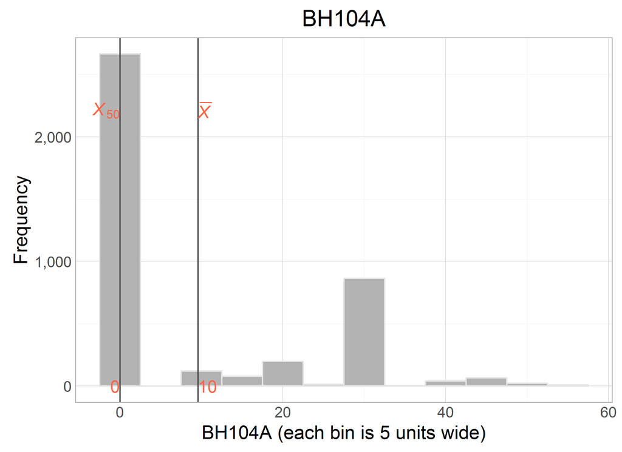

```r
dto[["unitData"]][["tilda"]]%>% dplyr::filter(!BH104A==-1)%>%histogram_continuous("BH104A", bin_width=5)
```

```r
dto[["unitData"]][["tilda"]]%>%dplyr::group_by_("BH104A")%>%dplyr::summarize(n=n())
```

```
Source: local data frame [20 x 2]

   BH104A     n
    (int) (int)
1      -1  4395
2       0  2666
3      10   118
4      12     3
5      13     2
6      14     1
7      15    77
8      16     1
9      19     1
10     20   198
11     25    14
12     30   864
13     35     2
14     36     1
15     40    42
16     45    66
17     50    24
18     55    10
19     56     1
20     NA    18
```

## BH105

```r
dto[["metaData"]]%>%dplyr::filter(study_name=="tilda", name=="BH105")%>%dplyr::select(name,label)
```

```
   name                                                                                 label
1 BH105 bh105  During the last 7 days, on how many days did you walk for at least 10 minutes?
```

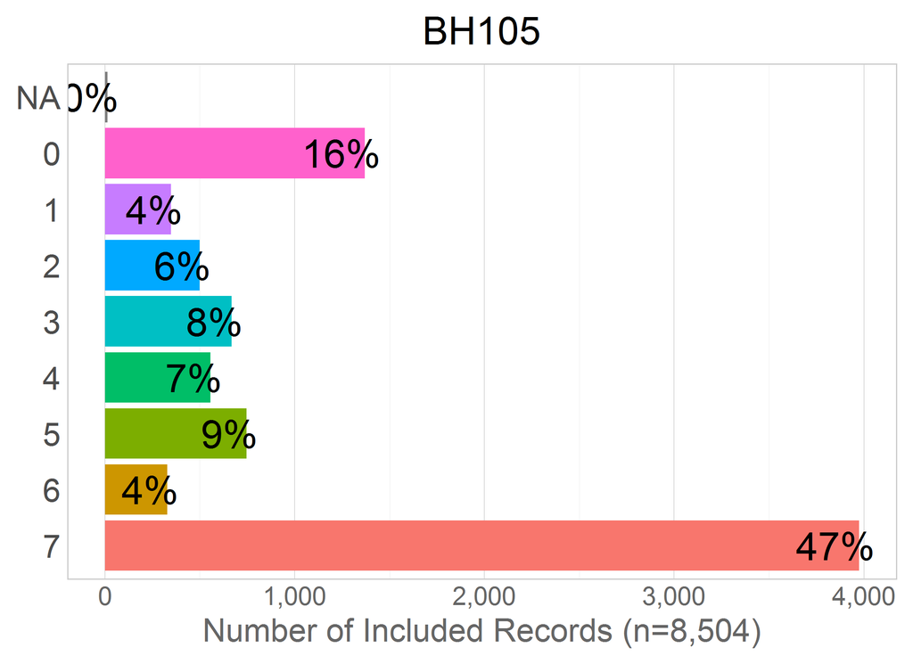

```r
dto[["unitData"]][["tilda"]]%>%histogram_discrete("BH105")
```

```r
dto[["unitData"]][["tilda"]]%>%dplyr::group_by_("BH105")%>%dplyr::summarize(n=n())
```

```
Source: local data frame [9 x 2]

  BH105     n
  (int) (int)
1     0  1369
2     1   349
3     2   499
4     3   668
5     4   557
6     5   746
7     6   328
8     7  3974
9    NA    14
```

## BH106

```r
dto[["metaData"]]%>%dplyr::filter(study_name=="tilda", name=="BH106")%>%dplyr::select(name,label)
```

```
   name                                                                          label
1 BH106 bh106  How much time did you usually spend walking on one of those days? HOURS
```

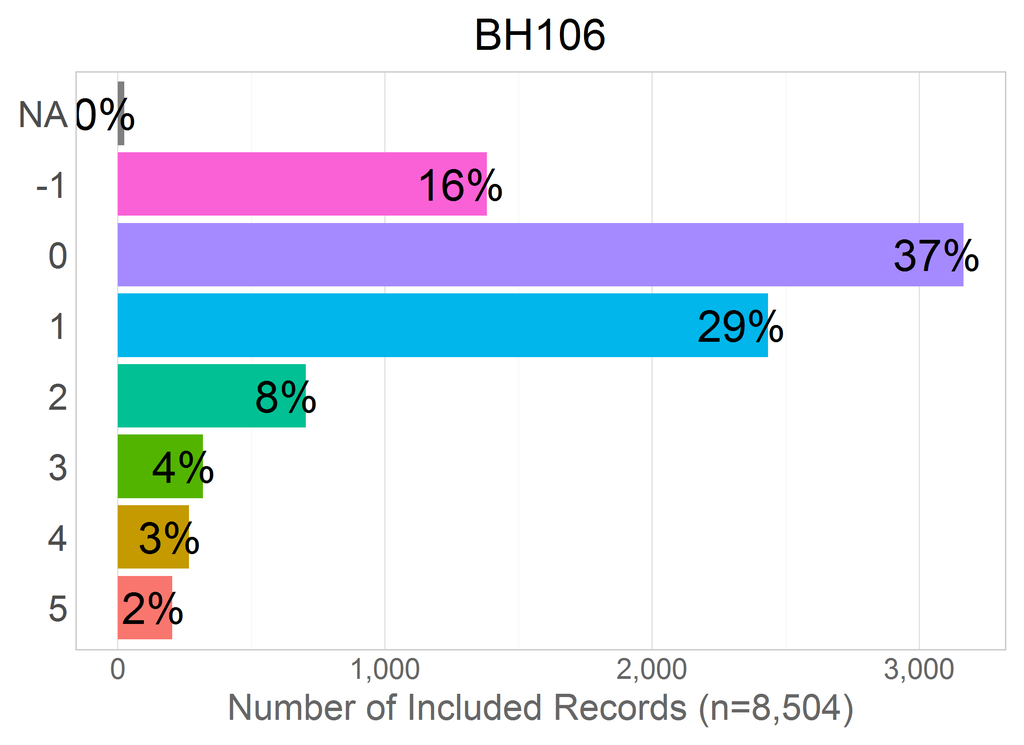

```r
dto[["unitData"]][["tilda"]]%>%histogram_discrete("BH106")
```

```r
dto[["unitData"]][["tilda"]]%>%dplyr::group_by_("BH106")%>%dplyr::summarize(n=n())
```

```
Source: local data frame [8 x 2]

  BH106     n
  (int) (int)
1    -1  1383
2     0  3166
3     1  2434
4     2   704
5     3   320
6     4   267
7     5   205
8    NA    25
```

## BH106A

```r
dto[["metaData"]]%>%dplyr::filter(study_name=="tilda", name=="BH106A")%>%dplyr::select(name,label)
```

```
    name                                                                          label
1 BH106A bh106a  How much time did you usually spend walking on one of those days? MINS
```

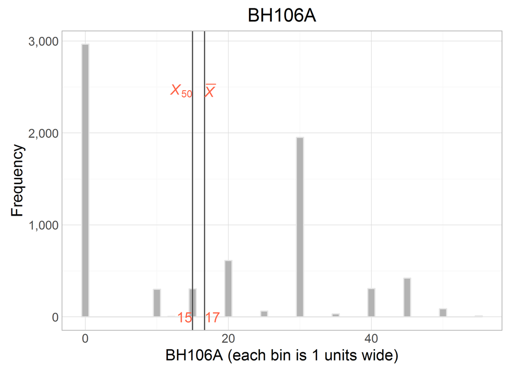

```r
dto[["unitData"]][["tilda"]]%>% dplyr::filter(!BH106A==-1)%>%histogram_continuous("BH106A", bin_width=1)
```

```r
dto[["unitData"]][["tilda"]]%>%dplyr::group_by_("BH106A")%>%dplyr::summarize(n=n())
```

```
Source: local data frame [24 x 2]

   BH106A     n
    (int) (int)
1      -1  1382
2       0  2966
3      10   302
4      12     6
5      13     2
6      15   305
7      18     2
8      20   615
9      24     2
10     25    65
..    ...   ...
```

## BH107

```r
dto[["metaData"]]%>%dplyr::filter(study_name=="tilda", name=="BH107")%>%dplyr::select(name,label)
```

```
   name                                                                                 label
1 BH107 bh107  During the last 7 days, how much time did you spend sitting on a week day? HO?
```

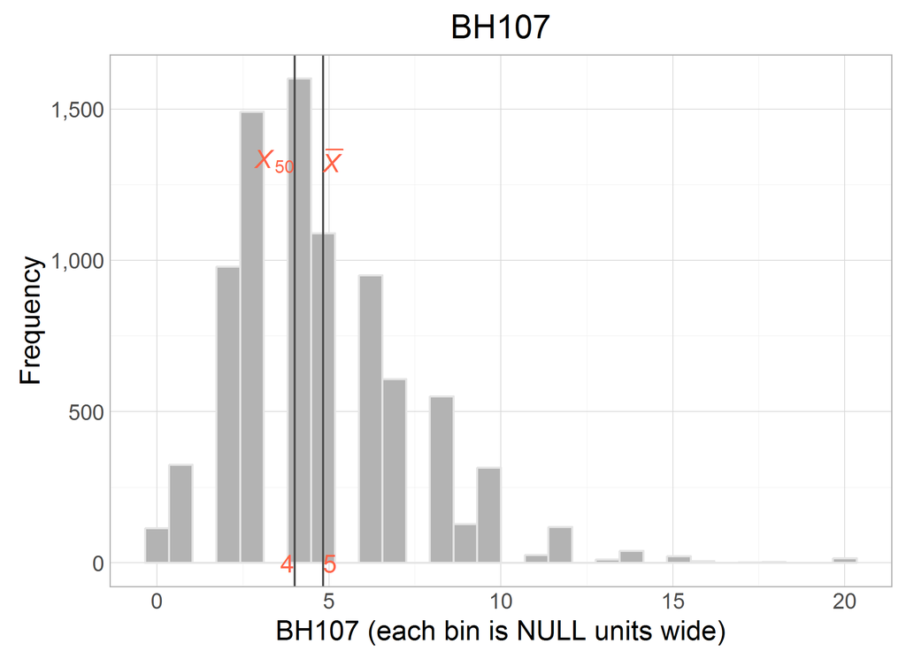

```r
dto[["unitData"]][["tilda"]]%>%histogram_continuous("BH107")
```

```r
dto[["unitData"]][["tilda"]]%>%dplyr::group_by_("BH107")%>%dplyr::summarize(n=n())
```

```
Source: local data frame [21 x 2]

   BH107     n
   (int) (int)
1      0   115
2      1   325
3      2   980
4      3  1491
5      4  1601
6      5  1090
7      6   951
8      7   608
9      8   551
10     9   128
..   ...   ...
```

## BH107A

```r
dto[["metaData"]]%>%dplyr::filter(study_name=="tilda", name=="BH107A")%>%dplyr::select(name,label)
```

```
    name                                                                                   label
1 BH107A bh107a  During the last 7 days, how much time did you spend sitting on a week day? MINS
```

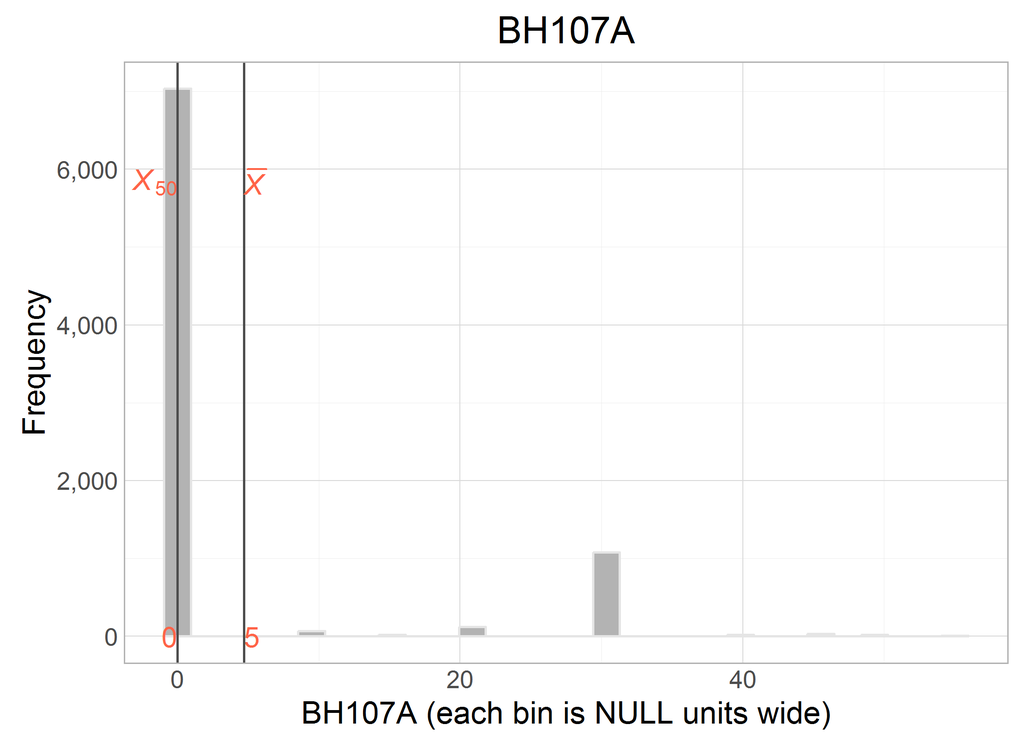

```r
dto[["unitData"]][["tilda"]]%>%histogram_continuous("BH107A")
```

```r
dto[["unitData"]][["tilda"]]%>%dplyr::group_by_("BH107A")%>%dplyr::summarize(n=n())
```

```
Source: local data frame [14 x 2]

   BH107A     n
    (int) (int)
1       0  7033
2      10    67
3      15    19
4      16     1
5      20   120
6      23     1
7      25     4
8      30  1079
9      35     5
10     40    23
11     45    31
12     50    19
13     55     7
14     NA    95
```